# Linear Regression: Day 3

Author

Constantin Manuel Bosancianu

Published

February 27, 2019

# 1 Introduction

We first start with yesterday’s data set on SAT scores in the US states - just a few more results, and we can put it behind us.

```r
library(pacman)
p_load(readstata13, tidyverse, psych, interplot, car, knitr,
       texreg, dotwhisker, effects, clarify, kableExtra,
       magrittr, ggthemes)

# Avoid scientific notation for coefficients
options(scipen = 8)
```

Also define the centering function we wrote yesterday.

```r
fun_center <- function(x) {
    x - mean(x, na.rm = TRUE)
}
```

# 2 Reading data

We read in the data we saved at the end of yesterday.

```r
df_sat <- read.csv(file = "../02-data/02-Education-states-followup.csv",
                   header = TRUE)
```

# 3 Categorical predictors

Re-estimate the last model we ran in yesterday’s session.

```r
model1 <- lm(csat ~ exp_scale + per_scale,
             data = df_sat,
             na.action = na.omit)
summary(model1)
```

```
Call:
lm(formula = csat ~ exp_scale + per_scale, data = df_sat, na.action = na.omit)

Residuals:
    Min      1Q  Median      3Q     Max
-62.921 -24.318   1.741  15.502  75.623

Coefficients:
              Estimate Std. Error t value Pr(>|t|)
(Intercept) 944.098039   4.428048 213.209  < 2e-16 ***
exp_scale     0.008604   0.004204   2.046   0.0462 *
per_scale    -2.537700   0.224912 -11.283 4.21e-15 ***
---
Signif. codes:  0 '***' 0.001 '**' 0.01 '*' 0.05 '.' 0.1 ' ' 1

Residual standard error: 31.62 on 48 degrees of freedom
Multiple R-squared:  0.7857,    Adjusted R-squared:  0.7768
F-statistic: 88.01 on 2 and 48 DF,  p-value: < 2.2e-16
```

We noticed in the first day fairly large regional differences in terms of SAT scores.

```r
df_sat %>%
    group_by(region) %>%
    summarise(CSAT = mean(csat, na.rm = TRUE)) %>%
    ungroup() %>%
    kable(caption = "Average CSAT scores by region",
          caption.above = TRUE,
          col.names = c("Region", "CSAT")) %>%
    kable_styling(full_width = TRUE)
```

Average CSAT scores by region

| Region | CSAT |
| --- | --- |
| Midwest | 1010.0833 |
| N. East | 889.5556 |
| South | 930.0000 |
| West | 946.3077 |
| NA | 840.0000 |

One lingering issue is whether the regional distinctions we observed are due to differences in education spending, or percentage of graduates taking the SAT, or rather another factor?

Recode this region indicator into a dummy variable, measuring whether the state is in the Northeast region or not.[^1]

<sup>1</sup> The annoying part is that the District of Columbia is not actually part of a region. So as not to lose the case, I coded it manually as belonging to the North East.

```r
df_sat %<>%
    mutate(region = as.character(region),
           neast = if_else(region == "N. East", 1, 0),
           neast = if_else(state == "District of Columbia",
                           1, neast))
```

```r
model2 <- lm(csat ~ exp_scale + per_scale + neast,
             data = df_sat,
             na.action = na.omit)

summary(model2)
```

```
Call:
lm(formula = csat ~ exp_scale + per_scale + neast, data = df_sat,
    na.action = na.omit)

Residuals:
    Min      1Q  Median      3Q     Max
-61.363 -19.619  -3.207  17.008  72.165

Coefficients:
              Estimate Std. Error t value Pr(>|t|)
(Intercept) 934.891177   5.114180 182.804  < 2e-16 ***
exp_scale     0.003477   0.004248   0.819  0.41718
per_scale    -2.856530   0.233554 -12.231 3.28e-16 ***
neast        46.954995  15.606341   3.009  0.00421 **
---
Signif. codes:  0 '***' 0.001 '**' 0.01 '*' 0.05 '.' 0.1 ' ' 1

Residual standard error: 29.26 on 47 degrees of freedom
Multiple R-squared:  0.8203,    Adjusted R-squared:  0.8089
F-statistic: 71.53 on 3 and 47 DF,  p-value: < 2.2e-16
```

It will be a bit easier if we have the models in a comparison table, so this next section of code simply does this table and displays it on the screen.[^2]

<sup>2</sup> The `screenreg()` function is from the `texreg` package.

```r
screenreg(list(model1, model2),
          digits = 3)
```

```r
htmlreg(list(model1, model2),
        digits = 3,
        single.row = FALSE,
        custom.model.names = c("Model 1", "Model 2"),
        custom.coef.names = c("(Intercept)", "Spending (centered)",
                              "% taking SAT (centered)", "Northeast"),
        caption = "Two comparison regression models",
        caption.above = TRUE,
        head.tag = FALSE, body.tag = FALSE, inline.css = TRUE,
        doctype = FALSE, html.tag = FALSE)
```

Two comparison regression models

|  | Model 1 | Model 2 |
| --- | --- | --- |
| (Intercept) | 944.098*** | 934.891*** |
|  | (4.428) | (5.114) |
| Spending (centered) | 0.009* | 0.003 |
|  | (0.004) | (0.004) |
| % taking SAT (centered) | -2.538*** | -2.857*** |
|  | (0.225) | (0.234) |
| Northeast |  | 46.955** |
|  |  | (15.606) |
| R<sup>2</sup> | 0.786 | 0.820 |
| Adj. R<sup>2</sup> | 0.777 | 0.809 |
| Num. obs. | 51 | 51 |

***p < 0.001; **p < 0.01; *p < 0.05

**Questions**:

1. How do you interpret the effect of being a state in the North East?
2. How come it’s now **positive**?

```r
df_sat %>%
    group_by(neast) %>%
    summarise(PERCENT = mean(percent, na.rm = TRUE),
              CSAT = mean(csat, na.rm = TRUE)) %>%
    ungroup() %>%
    kable(caption = "Relationship between cohort size and CSAT score across regional groups", # nolint
          caption.above = TRUE,
          col.names = c("Region", "% students taking SAT", "CSAT score")) %>%
    kable_styling(full_width = TRUE)
```

Relationship between cohort size and CSAT score across regional groups

| Region | % students taking SAT | CSAT score |
| --- | --- | --- |
| 0 | 26.90244 | 958.6098 |
| 1 | 72.10000 | 884.6000 |

Multiple categories can also be handled easily. Say that instead of just comparing the North East with everyone else, we wanted to see how each region is doing. That can also be checked very easily.[^3]

<sup>3</sup> `as.factor()` turns a categorical variables into a set of dummy indicators.

```r
model3 <- lm(csat ~ exp_scale + per_scale + as.factor(region),
             data = df_sat,
             na.action = na.omit)

summary(model3)
```

```
Call:
lm(formula = csat ~ exp_scale + per_scale + as.factor(region),
    data = df_sat, na.action = na.omit)

Residuals:
    Min      1Q  Median      3Q     Max
-46.973 -14.401  -0.954  14.570  58.275

Coefficients:
                           Estimate Std. Error t value Pr(>|t|)
(Intercept)              955.824532   9.068809 105.397  < 2e-16 ***
exp_scale                  0.002258   0.004448   0.508   0.6143
per_scale                 -2.605534   0.245565 -10.610 1.04e-13 ***
as.factor(region)N. East  25.007620  17.176387   1.456   0.1525
as.factor(region)South   -31.010120  11.837994  -2.620   0.0120 *
as.factor(region)West    -22.604319  11.452588  -1.974   0.0547 .
---
Signif. codes:  0 '***' 0.001 '**' 0.01 '*' 0.05 '.' 0.1 ' ' 1

Residual standard error: 26.71 on 44 degrees of freedom
  (1 observation deleted due to missingness)
Multiple R-squared:  0.8526,    Adjusted R-squared:  0.8358
F-statistic: 50.88 on 5 and 44 DF,  p-value: < 2.2e-16
```

The omitted category in this case is “Midwest”. How would you interpret the intercept value in this case? Furthermore, how would you interpret the value of the coefficient for “North East”?

If you’re not happy with the reference category selected automatically by `R`, you can always force a specific reference category with the aid of a small function: `relevel()`.

```r
df_sat %<>%
    mutate(region = as.factor(region))

df_sat <- within(df_sat, region <- relevel(region, ref = "South"))
```

```r
model4 <- lm(csat ~ exp_scale + per_scale + as.factor(region),
             data = df_sat,
             na.action = na.omit)

summary(model4)
```

```
Call:
lm(formula = csat ~ exp_scale + per_scale + as.factor(region),
    data = df_sat, na.action = na.omit)

Residuals:
    Min      1Q  Median      3Q     Max
-46.973 -14.401  -0.954  14.570  58.275

Coefficients:
                           Estimate Std. Error t value Pr(>|t|)
(Intercept)              924.814412   7.353523 125.765  < 2e-16 ***
exp_scale                  0.002258   0.004448   0.508 0.614278
per_scale                 -2.605534   0.245565 -10.610 1.04e-13 ***
as.factor(region)Midwest  31.010120  11.837994   2.620 0.012036 *
as.factor(region)N. East  56.017740  15.229646   3.678 0.000636 ***
as.factor(region)West      8.405801  10.232280   0.821 0.415792
---
Signif. codes:  0 '***' 0.001 '**' 0.01 '*' 0.05 '.' 0.1 ' ' 1

Residual standard error: 26.71 on 44 degrees of freedom
  (1 observation deleted due to missingness)
Multiple R-squared:  0.8526,    Adjusted R-squared:  0.8358
F-statistic: 50.88 on 5 and 44 DF,  p-value: < 2.2e-16
```

Just remember, forcing a reference category will also change the interpretation of the intercept, compared to the previous model. However, the interpretation of the other predictors is not changed. Nor is their effect size altered.

```r
rm(df_sat, model1, model2, model3, model4)
```

# 4 Regression inference

We start with a new data set today, obtained from Round 7 of the *European Social Survey*. The data refers to Great Britain, and was collected in 2014. As the data is in .CSV format, both `R` and `Stata` users will have to work with the codebook (**Codebook-ESS-data.pdf**).

```r
df_ess_uk <- read.csv(file = "../02-data/03-Practice-data-ess.csv",
                      header = TRUE)
```

Now, before we start, it is only fair to say that the most proper model for this data is not a linear regression, but rather an ordered logit. This would treat the measurement scale of satisfaction with democracy as a proper set of 11 categories, arranged in order of intensity, and not as a continuous scale (where *any* value between 0 and 10 is possible). The dangers in using a linear regression on such a 0-10 ordered scale are that predictions frequently fall in between adjacent categories (e.g., 3.675), or that predictions might fall outside of the bounds of the scale (e.g., 12). Nevertheless, I will use such a model for this dependent variable.

There are two main reasons for this. For one, you frequently encounter such models being used for ordinal data in applied work, so it’s worthwhile to show an example. Second, very frequently the substantive results from a linear model will be very similar to those obtained with a ordered logit. In this sense, then, we are not abusing the data as much as would seem at first glance. Even so, I’d like to stress this once more: the most appropriate model for this dependent variable is an ordered logit.

If we are being honest, there are not that many variables in voting behavior that are truly continuous, and therefore suitable for a linear model estimated with OLS.

## 4.1 Examine data

```r
df_ess_uk %>%
    glimpse()
```

```
Rows: 2,264
Columns: 9
$ stfdem   <int> 7, 6, 3, 7, 1, 1, 5, 7, 7, 4, 7, 2, 2, 9, 5, 6, 7, 0, 10, 1, …
$ male     <int> 0, 0, 1, 1, 1, 0, 0, 0, 1, 1, 1, 1, 1, 0, 1, 0, 1, 0, 0, 1, 1…
$ agea     <int> 49, 45, 76, 50, 67, 31, 34, 44, 32, 58, 48, 15, 53, 65, 41, 4…
$ eduyrs   <int> 17, 18, 10, 9, 10, 11, 13, 11, 10, 9, 16, 11, 15, 14, 12, 18,…
$ mbtru    <int> 1, 1, 1, 0, 0, 1, 0, 1, 0, 1, 0, 0, 0, 0, 1, 0, 1, 1, 0, 1, 0…
$ hinctnta <int> 4, 2, 2, 6, 1, 5, 10, 2, 6, 7, 7, NA, NA, 4, 8, NA, 3, 6, 10,…
$ ppltrst  <int> 8, 4, 8, 8, 6, 2, 3, 9, 3, 7, 7, 5, 2, 8, 7, 7, 8, 0, 8, 8, 5…
$ clsprty  <int> 0, 0, 1, 0, 0, 0, 1, 0, 1, 0, 1, 0, 0, 1, 0, 1, 1, 1, 0, 0, 0…
$ age15    <int> 34, 30, 61, 35, 52, 16, 19, 29, 17, 43, 33, 0, 38, 50, 26, 25…
```

The `describe()` function is available in the `psych` package.

```r
describe(df_ess_uk$age15)
```

```
   vars    n mean    sd median trimmed   mad min max range  skew kurtosis   se
X1    1 2243 37.2 18.39     37   37.21 22.24   0  79    79 -0.01    -0.92 0.39
```

We can also plot the distribution of key variables.

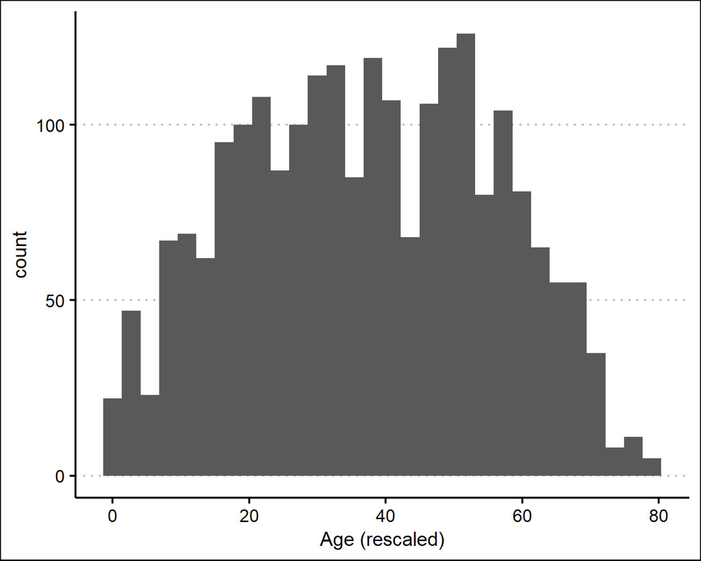

```r
ggplot(df_ess_uk, aes(x = age15)) +
    geom_histogram() +
    theme_clean() +
    xlab("Age (rescaled)")
```

```r
describe(df_ess_uk$eduyrs)
```

```
   vars    n  mean   sd median trimmed  mad min max range skew kurtosis   se
X1    1 2247 13.53 3.63     13   13.28 4.45   0  28    28  0.5     0.62 0.08
```

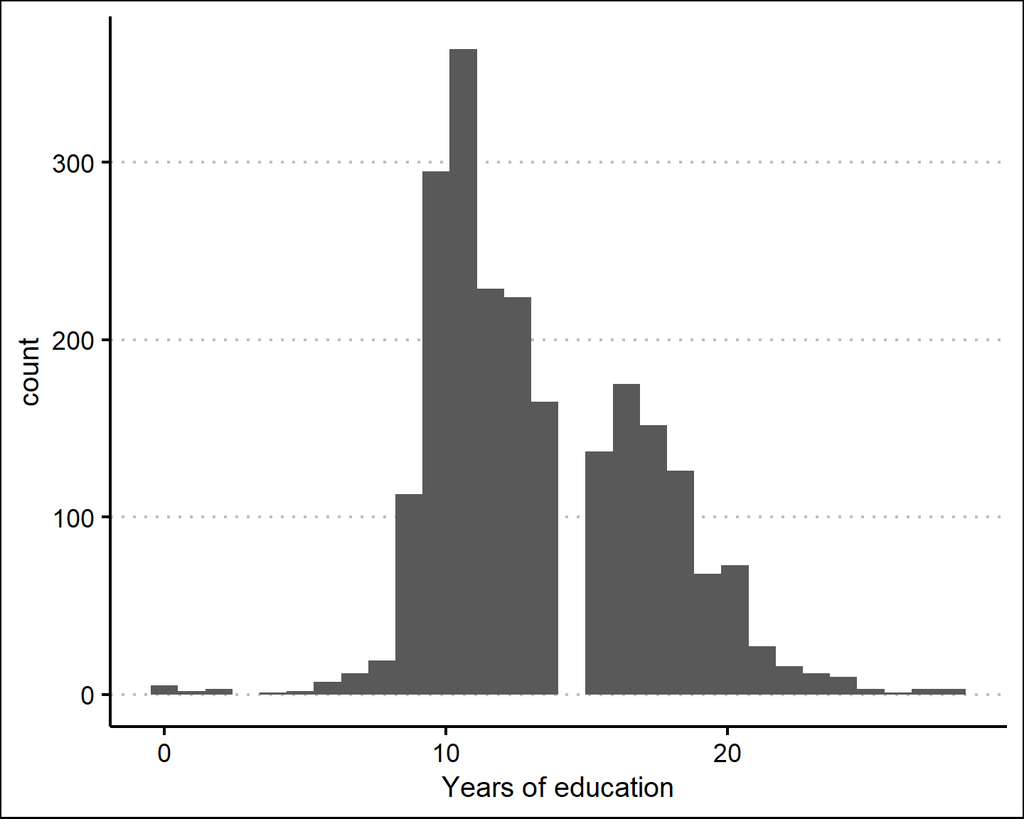

```r
ggplot(df_ess_uk, aes(x = eduyrs)) +
    geom_histogram() +
    theme_clean() +
    xlab("Years of education")
```

```r
describe(df_ess_uk$hinctnta)
```

```
   vars    n mean sd median trimmed  mad min max range skew kurtosis   se
X1    1 1901 4.95  3      5    4.82 4.45   1  10     9 0.25    -1.26 0.07
```

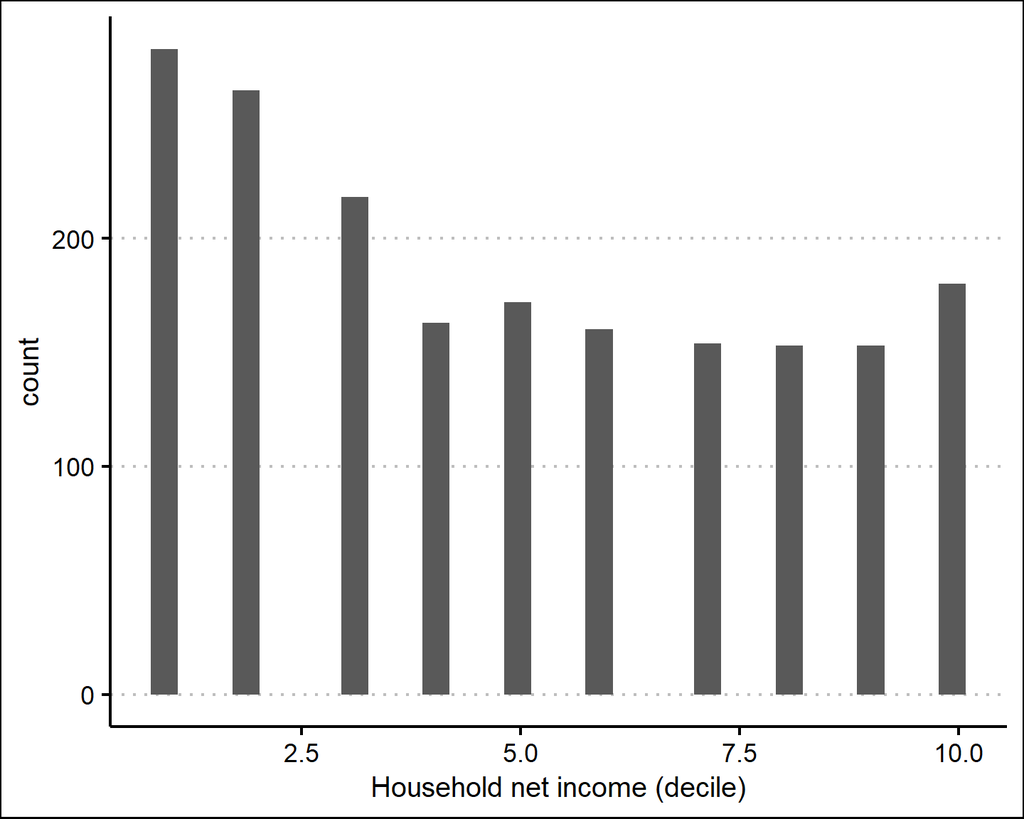

```r
ggplot(df_ess_uk, aes(x = hinctnta)) +
    geom_histogram() +
    theme_clean() +
    xlab("Household net income (decile)")
```

As before, we can also try a multivariate display.

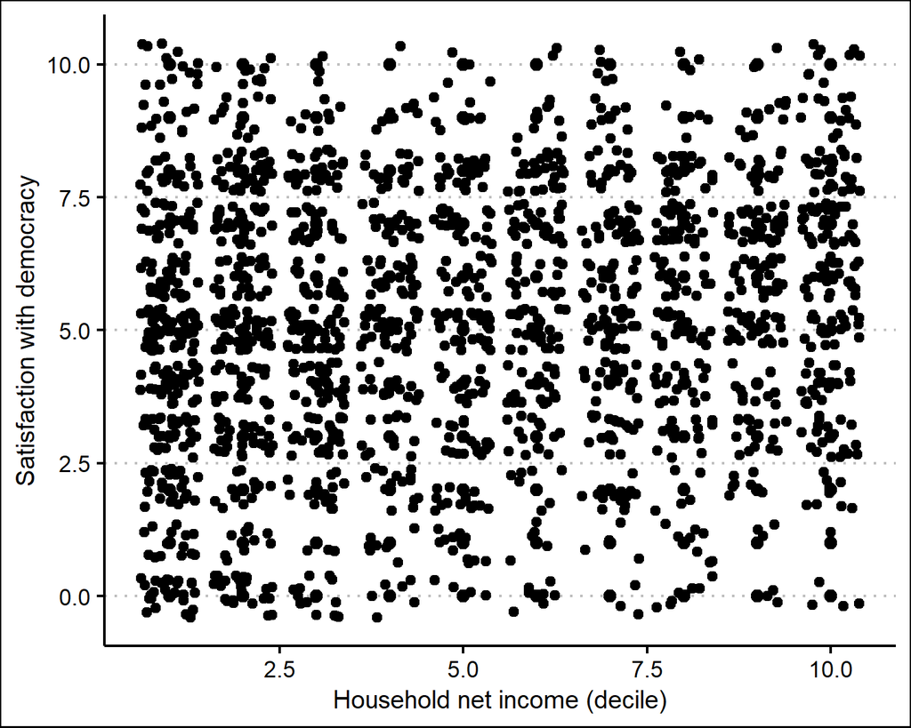

```r
ggplot(df_ess_uk,
       aes(x = hinctnta,
           y = stfdem)) +
    geom_point(size = 2) +
    geom_jitter() +
    labs(x = "Household net income (decile)",
         y = "Satisfaction with democracy") +
    theme_clean()
```

Unfortunately, scatterplots aren’t very useful in this case. Even with the jittering function, they can’t really show whether there is a relationship between the two variables. This is a standard occurrence when using ordered data with a limited number of categories.

A much more useful approach is to simply compute a mean of satisfaction with democracy for each level of income of our respondents. That ought to give us a rough idea whether higher income is associated with a higher level of satisfaction.

```r
df_ess_uk %>%
    group_by(hinctnta) %>%
    summarise(STF = mean(stfdem, na.rm = TRUE)) %>%
    kable(caption = "Average satisfaction by income group",
          caption.above = TRUE,
          col.names = c("Income decile", "Average satisfaction")) %>%
    kable_styling(full_width = TRUE)
```

Average satisfaction by income group

| Income decile | Average satisfaction |
| --- | --- |
| 1 | 4.650735 |
| 2 | 5.003968 |
| 3 | 4.962085 |
| 4 | 5.025478 |
| 5 | 5.095238 |
| 6 | 5.401274 |
| 7 | 5.300654 |
| 8 | 5.309210 |
| 9 | 5.671053 |
| 10 | 5.876404 |
| NA | 5.096970 |

Apart for some slight deviations, there seems to be a positive relationship between the two. As income increases, so does satisfaction with democracy.

```r
df_ess_uk %<>%
    mutate(educ06 = case_when(eduyrs <= 5 ~ 1,
                              eduyrs >= 6 & eduyrs <= 10 ~ 2,
                              eduyrs >= 11 & eduyrs <= 15 ~ 3,
                              eduyrs >= 16 & eduyrs <= 20 ~ 4,
                              eduyrs >= 21 & eduyrs <= 25 ~ 5,
                              eduyrs >=26 ~ 6))
```

```r
df_ess_uk %>%
    group_by(educ06) %>%
    summarise(STF = mean(stfdem, na.rm = TRUE)) %>%
    kable(caption = "Average satisfaction by educational group",
          caption.above = TRUE,
          col.names = c("Educational category", "Average satisfaction")) %>%
    kable_styling(full_width = TRUE)
```

Average satisfaction by educational group

| Educational category | Average satisfaction |
| --- | --- |
| 1 | 4.615385 |
| 2 | 4.850711 |
| 3 | 4.943978 |
| 4 | 5.700855 |
| 5 | 5.941177 |
| 6 | 6.571429 |
| NA | 5.437500 |

There also seems to be a positive relationship between these two variables. How is the correlation between these two predictors (education and income)?[^4]

<sup>4</sup> We use Spearman’s $\rho$ in this case, because the two indicators are ordinal.

```r
cor(df_ess_uk$eduyrs, df_ess_uk$hinctnta,
    use = "complete.obs",
    method = "spearman")
```

```
[1] 0.4132429
```

Before starting with the model, I will listwise delete all observations with missing information on any of the variables. This is so as to make sure that all models are estimated on exactly the same sample.[^5]

<sup>5</sup> It also means that in the `lm()` function below we won’t need to use the `na.action =` argument.

```r
df_ess_uk %<>%
    na.omit()
```

## 4.2 Inference

Start by running a simple model of satisfaction with democracy. First, though, let’s make sure income has a meaningful “0” value, so as to be able to interpret the intercept in a sensible way.

```r
df_ess_uk %<>%
    mutate(hinctnta = hinctnta - 1)
```

```r
model1 <- lm(stfdem ~ hinctnta,
             data = df_ess_uk)
summary(model1)
```

```
Call:
lm(formula = stfdem ~ hinctnta, data = df_ess_uk)

Residuals:
   Min     1Q Median     3Q    Max
-5.743 -1.743  0.177  1.947  5.292

Coefficients:
            Estimate Std. Error t value      Pr(>|t|)
(Intercept)  4.70799    0.09654  48.769       < 2e-16 ***
hinctnta     0.11496    0.01928   5.962 0.00000000298 ***
---
Signif. codes:  0 '***' 0.001 '**' 0.01 '*' 0.05 '.' 0.1 ' ' 1

Residual standard error: 2.474 on 1828 degrees of freedom
Multiple R-squared:  0.01907,   Adjusted R-squared:  0.01854
F-statistic: 35.55 on 1 and 1828 DF,  p-value: 0.000000002981
```

**Questions**:

1. How do you interpret the intercept in this instance?
2. How do you interpret the effect of income?
3. Are they statistically significant? How can you tell?

Using the information in the output, you could also compute by hand a 95% or 99% confidence interval for both the slope and the intercept. This isn’t really that important, as there is a function for this in `R`.

```r
confint.lm(model1, level = 0.95)
```

```
                 2.5 %    97.5 %
(Intercept) 4.51865668 4.8973225
hinctnta    0.07714658 0.1527823
```

```r
confint.lm(model1, level = 0.99)
```

```
                 0.5 %    99.5 %
(Intercept) 4.45906882 4.9569104
hinctnta    0.06524435 0.1646845
```

99% confidence intervals are wider than the 95% confidence intervals, but this is normal. If you want to have a higher degree of certainty, you’d better enlarge your universe of possibilities. Taking this to the limit, a 100% confidence interval will be… $-\infty$ to $+\infty$. Also note that there is nothing special about the 95% confidence level. It was chosen a long time ago (by R. A. Fisher) as a convenient threshold, and scientists have followed that convention to this day. It is just that, though: a convention. It doesn’t have deeper mathematical properties. If you wanted to you could use 0.10 or 0.15 as a threshold, although the power of a convention is strong: you will frequently have to justify the choice.

```r
model2 <- lm(stfdem ~ male + age15 + hinctnta + eduyrs,
             data = df_ess_uk)

summary(model2)
```

```
Call:
lm(formula = stfdem ~ male + age15 + hinctnta + eduyrs, data = df_ess_uk)

Residuals:
    Min      1Q  Median      3Q     Max
-6.1045 -1.6824  0.2454  1.8334  5.8984

Coefficients:
            Estimate Std. Error t value     Pr(>|t|)
(Intercept) 2.774475   0.287790   9.641      < 2e-16 ***
male        0.366860   0.115357   3.180     0.001496 **
age15       0.014900   0.003376   4.414 0.0000107630 ***
hinctnta    0.079991   0.020912   3.825     0.000135 ***
eduyrs      0.098078   0.017088   5.740 0.0000000111 ***
---
Signif. codes:  0 '***' 0.001 '**' 0.01 '*' 0.05 '.' 0.1 ' ' 1

Residual standard error: 2.44 on 1825 degrees of freedom
Multiple R-squared:  0.04767,   Adjusted R-squared:  0.04559
F-statistic: 22.84 on 4 and 1825 DF,  p-value: < 2.2e-16
```

**Question**: What does it mean that the significance test for education produces a *p*-value that is much, much lower than the corresponding *p*-value for gender?

```r
confint.lm(model2, level = 0.95)
```

```
                  2.5 %     97.5 %
(Intercept) 2.210043413 3.33890724
male        0.140613921 0.59310538
age15       0.008278656 0.02152064
hinctnta    0.038976314 0.12100538
eduyrs      0.064564473 0.13159100
```

You can see from the F-test for Model 2 that at least some of the coefficients are not 0 (redundant information, given that we already examined the significance tests for each coefficient).

What if we wanted to compare Model 1 with Model 2, though? We could see whether any of the added predictors have effects that are different from 0.

```r
anova(model1, model2)
```

```
Analysis of Variance Table

Model 1: stfdem ~ hinctnta
Model 2: stfdem ~ male + age15 + hinctnta + eduyrs
  Res.Df   RSS Df Sum of Sq      F           Pr(>F)
1   1828 11187
2   1825 10861  3    326.16 18.268 0.00000000001115 ***
---
Signif. codes:  0 '***' 0.001 '**' 0.01 '*' 0.05 '.' 0.1 ' ' 1
```

# 5 Presenting results

## 5.1 Coefficient tables

In most journals, you will likely be required to present a table of regression results, as we generated yesterday. That’s the standard approach.

Let’s start by running an additional model, for comparison purposes.

```r
model3 <- lm(stfdem ~ male + age15 + hinctnta + eduyrs +
                 mbtru + ppltrst,
             data = df_ess_uk)

summary(model3)
```

```
Call:
lm(formula = stfdem ~ male + age15 + hinctnta + eduyrs + mbtru +
    ppltrst, data = df_ess_uk)

Residuals:
    Min      1Q  Median      3Q     Max
-6.7370 -1.7050  0.2545  1.7396  6.2015

Coefficients:
             Estimate Std. Error t value        Pr(>|t|)
(Intercept)  2.005143   0.293754   6.826 0.0000000000119 ***
male         0.406652   0.112977   3.599        0.000327 ***
age15        0.015928   0.003474   4.585 0.0000048440714 ***
hinctnta     0.071601   0.020488   3.495        0.000486 ***
eduyrs       0.083149   0.016945   4.907 0.0000010075458 ***
mbtru       -0.522642   0.117436  -4.450 0.0000090869740 ***
ppltrst      0.220753   0.026208   8.423         < 2e-16 ***
---
Signif. codes:  0 '***' 0.001 '**' 0.01 '*' 0.05 '.' 0.1 ' ' 1

Residual standard error: 2.382 on 1823 degrees of freedom
Multiple R-squared:  0.0934,    Adjusted R-squared:  0.09041
F-statistic:  31.3 on 6 and 1823 DF,  p-value: < 2.2e-16
```

```r
htmlreg(list(model2, model3),
        digits = 2,
        single.row = FALSE,
        custom.model.names = c("Small model",
                               "Larger model"),
        custom.coef.names = c("(Intercept)", "Gender (male)", "Age (centered at 15)", # nolint
                              "Income (deciles)", "Education (years)",
                              "Union membership", "Interpersonal trust"),
        caption = "Two comparison regression models",
        caption.above = TRUE,
        head.tag = FALSE, body.tag = FALSE, inline.css = TRUE,
        doctype = FALSE, html.tag = FALSE)
```

Two comparison regression models

|  | Small model | Larger model |
| --- | --- | --- |
| (Intercept) | 2.77*** | 2.01*** |
|  | (0.29) | (0.29) |
| Gender (male) | 0.37** | 0.41*** |
|  | (0.12) | (0.11) |
| Age (centered at 15) | 0.01*** | 0.02*** |
|  | (0.00) | (0.00) |
| Income (deciles) | 0.08*** | 0.07*** |
|  | (0.02) | (0.02) |
| Education (years) | 0.10*** | 0.08*** |
|  | (0.02) | (0.02) |
| Union membership |  | -0.52*** |
|  |  | (0.12) |
| Interpersonal trust |  | 0.22*** |
|  |  | (0.03) |
| R<sup>2</sup> | 0.05 | 0.09 |
| Adj. R<sup>2</sup> | 0.05 | 0.09 |
| Num. obs. | 1830 | 1830 |

***p < 0.001; **p < 0.01; *p < 0.05

## 5.2 Coefficient plots

The slightly cooler way is to present the coefficients graphically, and maybe put the table of actual results in the online appendix.[^6]

<sup>6</sup> The `dwplot()` function is available in the `dotwhisker` package.

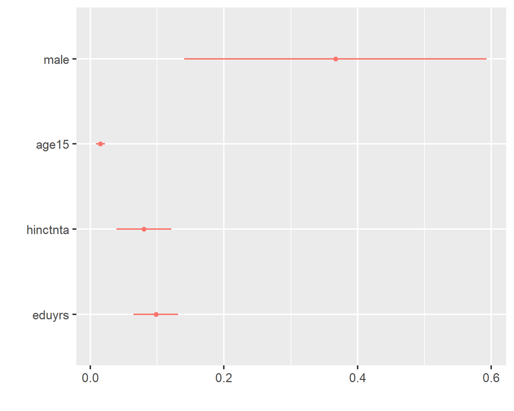

```r
dwplot(model2)
```

As before, the `dwplot()` function exports a “ggplot2” object, so you can customize it further with the standard functions in that package.

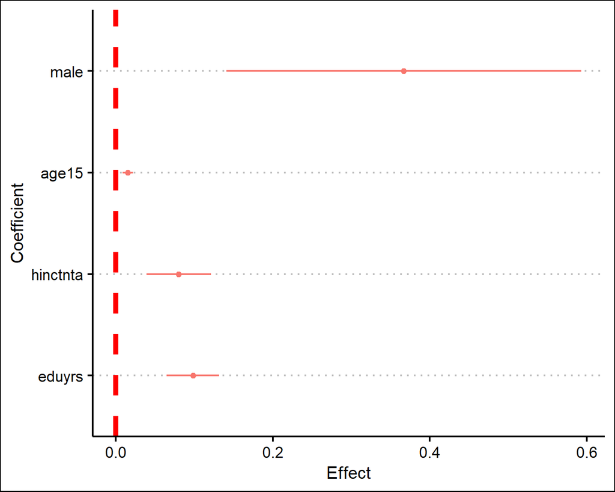

```r
dwplot(model2) +
    xlab("Effect") +
    ylab("Coefficient") +
    geom_vline(xintercept = 0,
               linetype = "dashed",
               linewidth = 1.5,
               color = "red") +
    theme_clean() +
    theme(legend.position = "none") # Removes the legend, which is a
```

```r
                                    # bit useless in this case
```

You can even do slightly more sophisticated things with it, like comparing different model estimates.

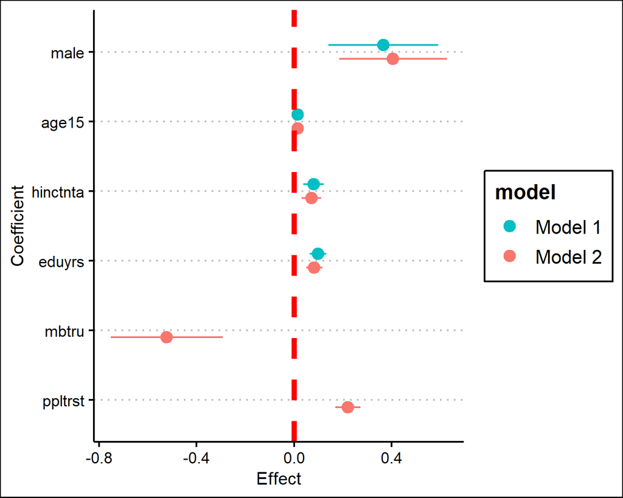

```r
dwplot(list(model2, model3),
       dot_args = list(size = 3)) +
    xlab("Effect") +
    ylab("Coefficient") +
    geom_vline(xintercept = 0,
               linetype = "dashed",
               linewidth = 1.5,
               color = "red") +
    theme_clean()
```

You can further customize the plot by having nice variable names for the predictors.

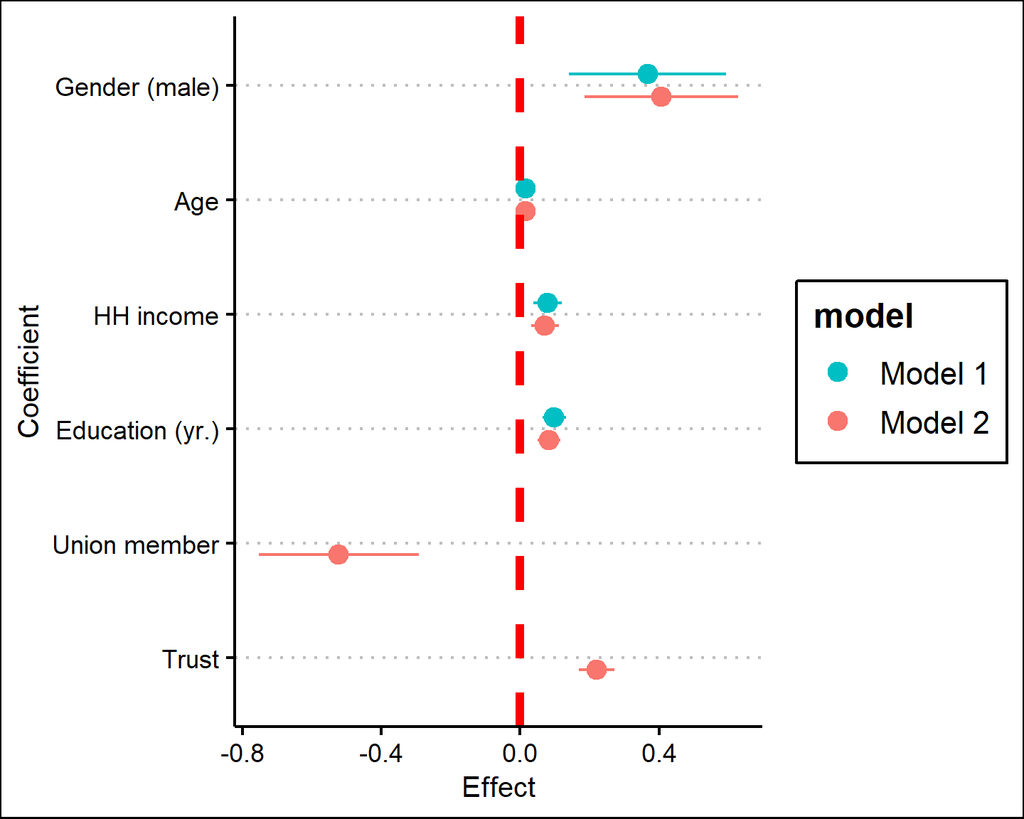

```r
dwplot(list(model2, model3),
       dot_args = list(size = 3)) +
    xlab("Effect") +
    ylab("Coefficient") +
    geom_vline(xintercept = 0,
               linetype = "dashed",
               linewidth = 1.5,
               color = "red") +
    theme_clean() +
    scale_y_discrete(breaks = c("male", "age15", "hinctnta",
                                "eduyrs", "mbtru", "ppltrst"),
                     labels = c("Gender (male)", "Age", "HH income",
                                "Education (yr.)", "Union member",
                                "Trust"))
```

## 5.3 Effect plots

The final way, though, is my favorite. There are multiple reasons for this, but the main one is that it presents what people actually care about: how does the outcome change when the predictor changes?

Coefficients are not so intuitive for an audience that has had no contact with statistics. Changes in the outcome are simple enough for most people to understand.

```r
eff1 <- Effect("eduyrs", # Which predictor are we interested in
               model2, # Which model estimates do we want
               xlevels = list(eduyrs = c(9:19)), # For which levels of
                                        # the predictor to compute
                                        # effects
               se = TRUE) # We want uncertainty measures (the default)

# Simple display of effects
eff1
```

```
 eduyrs effect
eduyrs
       9       10       11       12       13       14       15       16
4.706226 4.804303 4.902381 5.000459 5.098537 5.196614 5.294692 5.392770
      17       18       19
5.490848 5.588925 5.687003
```

We can further plot these effects.

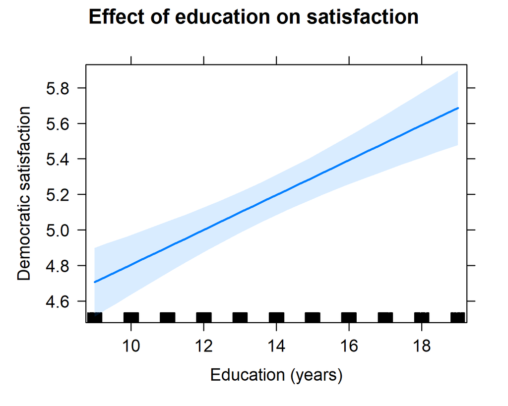

```r
plot(eff1,
     main = "Effect of education on satisfaction",
     xlab = "Education (years)",
     ylab = "Democratic satisfaction")
```

## 5.4 The `clarify` magic

`clarify` works with the regression object fitted with `lm()`[^7], so there is not much additional work to do here. `clarify` only starts to kick in when we take this fitted regression object, and begin to *simulate* the coefficients.

<sup>7</sup> In fact, it accepts objects fitted by many other functions, which makes it conventient to work with.

The key difference from the previous methods is that until now they presented either raw coefficients, or *predicted* values. `clarify` presents *simulated* values, which incorporate both uncertainty from SEs, as well as uncertainty generated by the fact that the model does not fit the data perfectly.

Here is how the authors of the package describe the issue: “Although regression models are frequently used in empirical research to study relationships among variables, often the quantity of substantive interest is not one of the coefficients of the model, but rather a quantity derived from the coefficients, such as predicted values or average marginal effects. The usual method for estimating the uncertainty of the derived quantities is an approximation known as the *delta method*. The delta method involves two approximations: 1) that the variance of the derived quantity can be represented as a first-order Taylor series, and 2) that the resulting estimate is normally distributed. In many cases, especially with nonlinear models, these approximation can fail badly. `clarify` implements an alternative to the delta method—simulation-based inference—which involves simulating the sampling distributions of the derived quantities.”[^8]

<sup>8</sup> See more details at: https://iqss.github.io/clarify/articles/clarify.html.

```r
set.seed(156286) # A random seed, which ensures results are replicable
m3_sim <- sim(model3)
```

From this point onward, it’s all `clarify`. Set some interesting values for a predictor you’re interested in, and see how the outcome varies. You can easily do this with the `sim_setx()` function.

```r
m3_est <- sim_setx(m3_sim,
                   x = list(hinctnta = 2),
                   x1 = list(hinctnta = 7),
                   verbose = FALSE)
summary(m3_est)
```

```
             Estimate 2.5 % 97.5 %
hinctnta = 2    5.077 4.880  5.271
hinctnta = 7    5.435 5.198  5.686
FD              0.358 0.159  0.560
```

Instead of presenting raw numbers, we can plot these results.[^9]

<sup>9</sup> `FD` on the plot refers to the difference in the outcome by going from the lower value of the key predictor to the higher value.

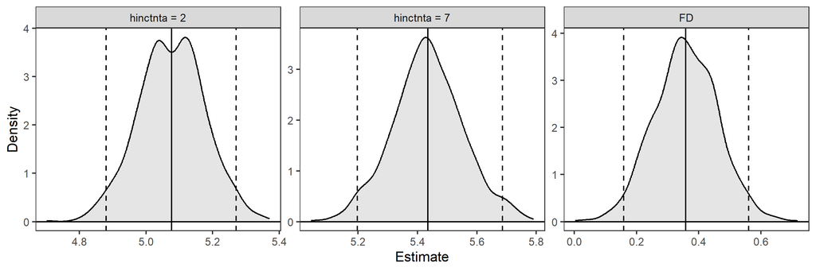

```r
plot(m3_est)
```

The cool thing is that the “sim_setx()” approach can work even for more than 1 variable at the same time.

```r
m3_est <- sim_setx(m3_sim,
                   x = list(hinctnta = 2, ppltrst = 2),
                   x1 = list(hinctnta = 7, ppltrst = 8),
                   verbose = FALSE)
```

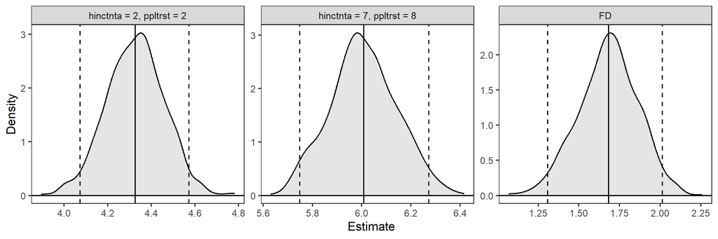

```r
plot(m3_est)
```

# 6 Package versions